# Projekt Zaliczeniowy

Kaja Dudek, Julia Smerdel

27.01.2023

## Projekt

Projekt polega na prostym opracowaniu statystycznym wyników porównania działania wybranych algorytmów minimalizacji stochastycznej. Do porównania zostałe wybrane algorytmy **Poszukiwania przypadkowego PRS** oraz **Algorytm genetyczny GA**.

Działanie algorytmów sprawdzane było na podstawie dwóch funkcji skalarnych, wielomodalnych i posiadających wersje dla różnej liczby wymiarów. Wybrane zostały funkcje **Ackley’a** (dziedzina: -32.8; 32.8; wartość minimalna: 0) oraz **Rastrigina** (dziedzina: -5.12; 5.12; wartość minimalna: 0).

Użyte biblioteki: smoof, ecr.

Budżet obliczeniowy każdego z algorytmów (liczba wywołań minimalizowanej funkcji) wynosi 1000 wywołań. Średni wynik każdego z algorytmu (czyli średnia znalezionych minimów) liczony jest z 50 uruchomień każdego algorytmu osobno dla każdej funkcji i dla każdej liczby wymiarów.

## Poszukiwanie przypadkowe PRS

*Ackley*

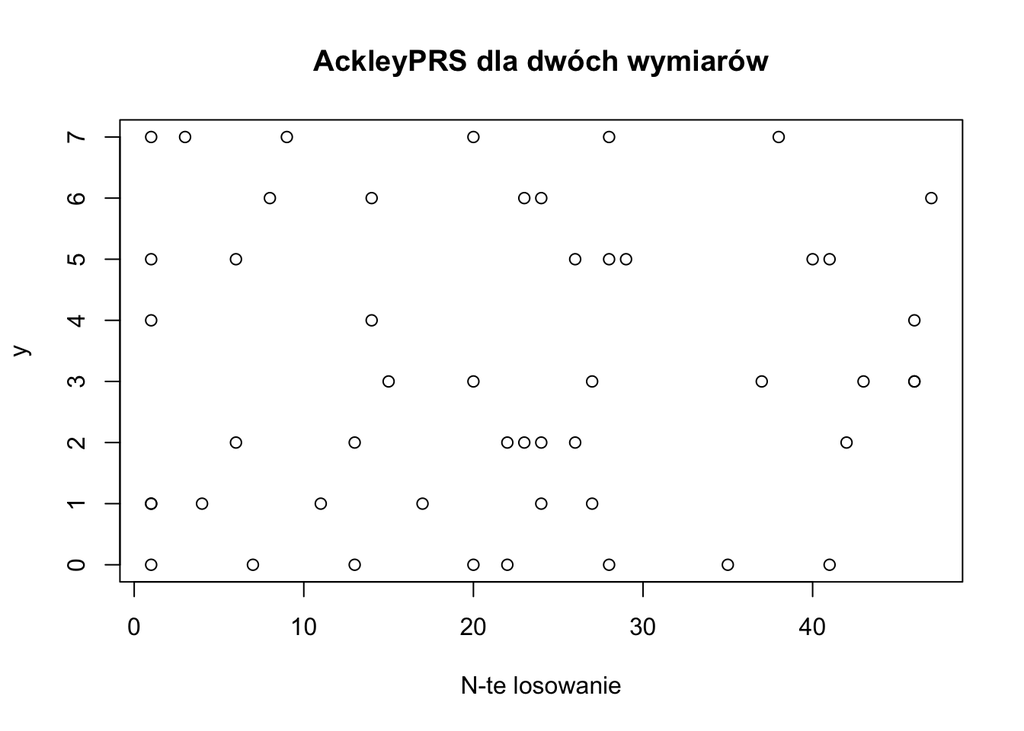

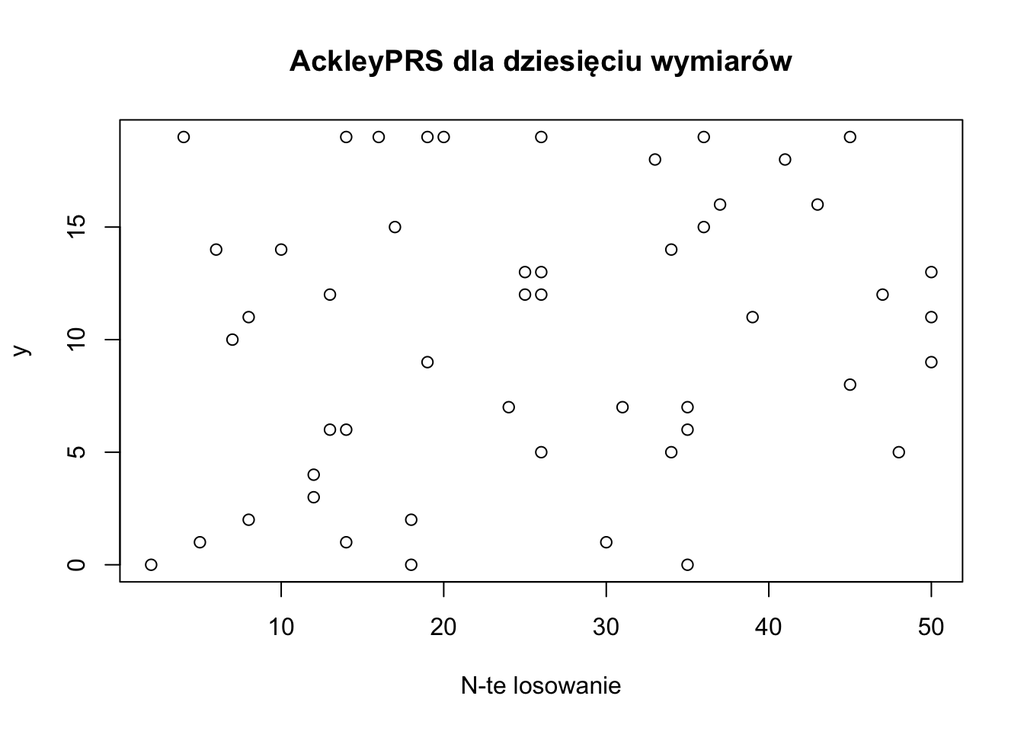

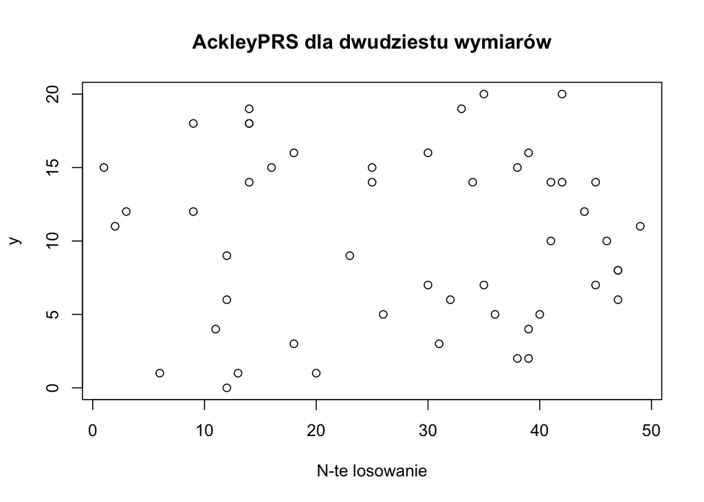

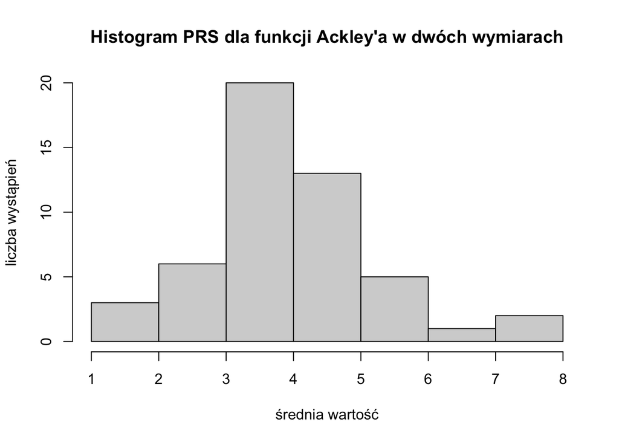

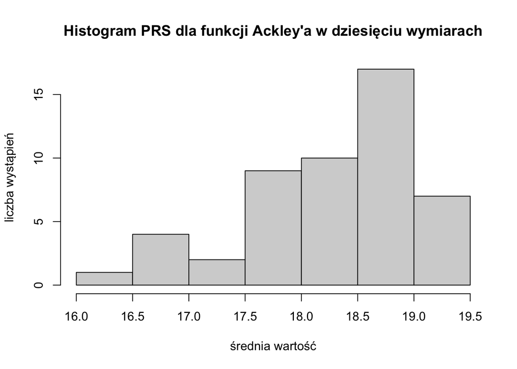

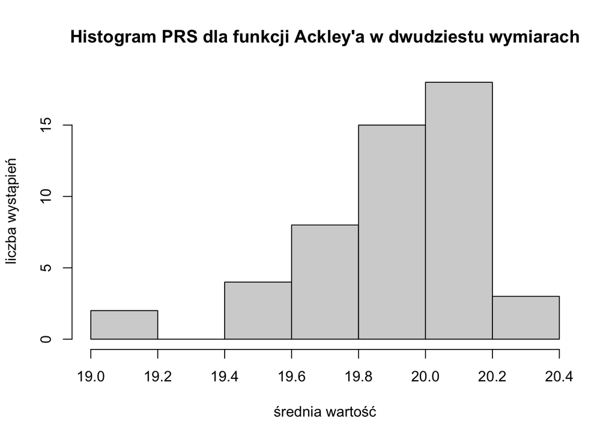

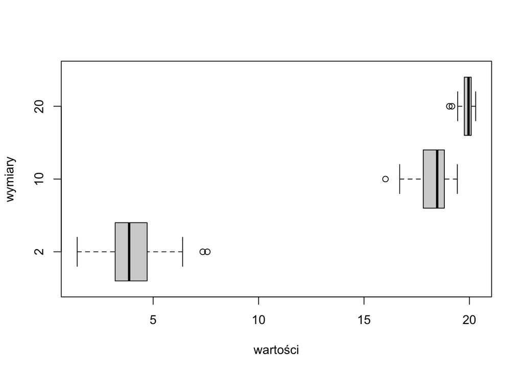

Łatwo zauważyć, że korzystając z algorytmu Poszukiwania przypadkowego wyniki nie są zgodne z powyższym stwierdzeniem. Im wyższy wymiar, tym większa wartość minimalna funkcji.

Wykresy pudełkowe pokazują, że największy zasięg wartości, które leżą powyżej górnego i poniżej dolnego kwartyla występuje dla funkcji 2 wymiarów. Ma ona również największe rozproszenie. Najmniejsze rozproszenie otrzymałyśmy dla wyników funkcji w 20 wymiarach. Na podstawie histogramów można zaobserwować, że ta funkcja wraz z funkcją 10 wymiarów mają także najmniejsze zróżnicowanie wyników, a najliczniejszy przedział mieści się w granicach 18-20, co jest sporym odstępstwem od wartości funkcji w 2 wymiarach.

*Rastrigin*

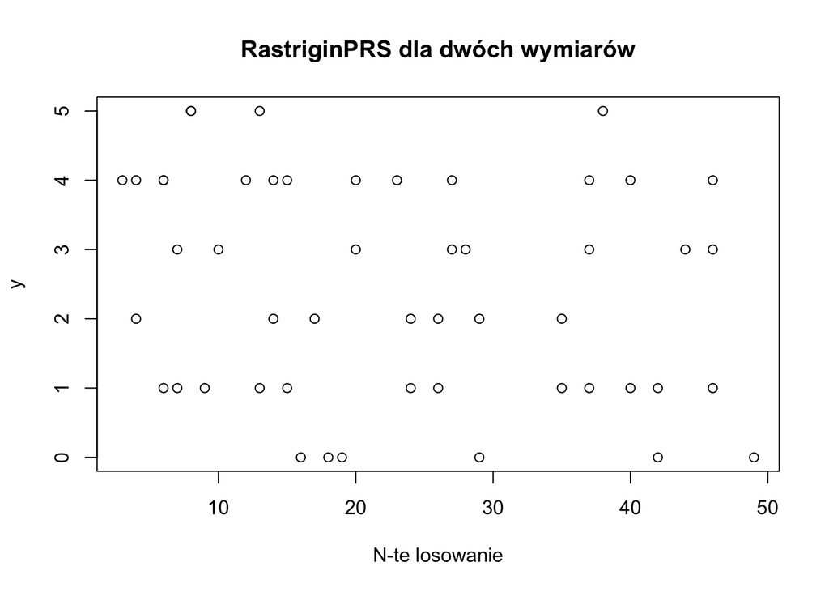

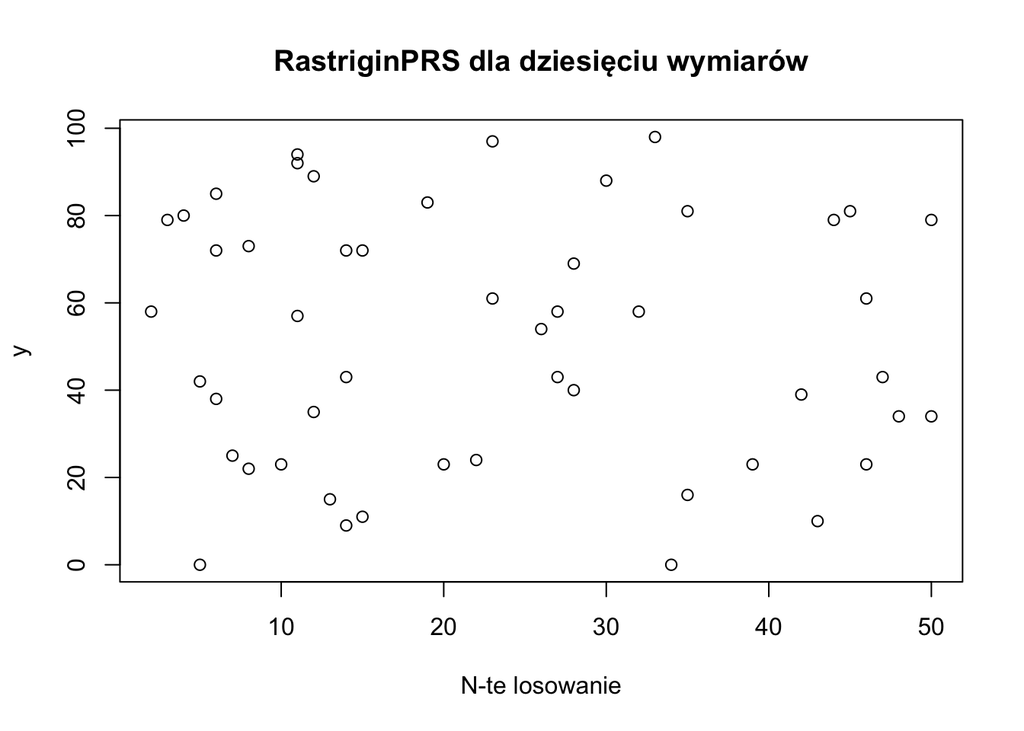

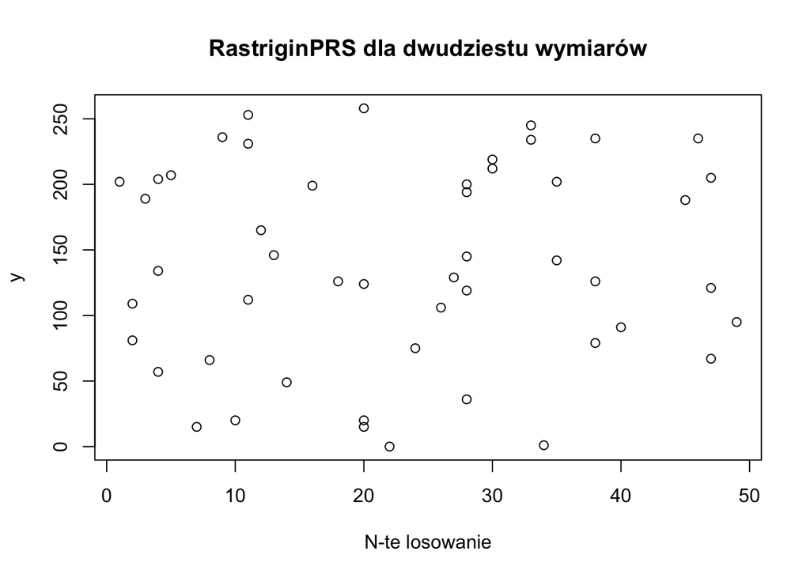

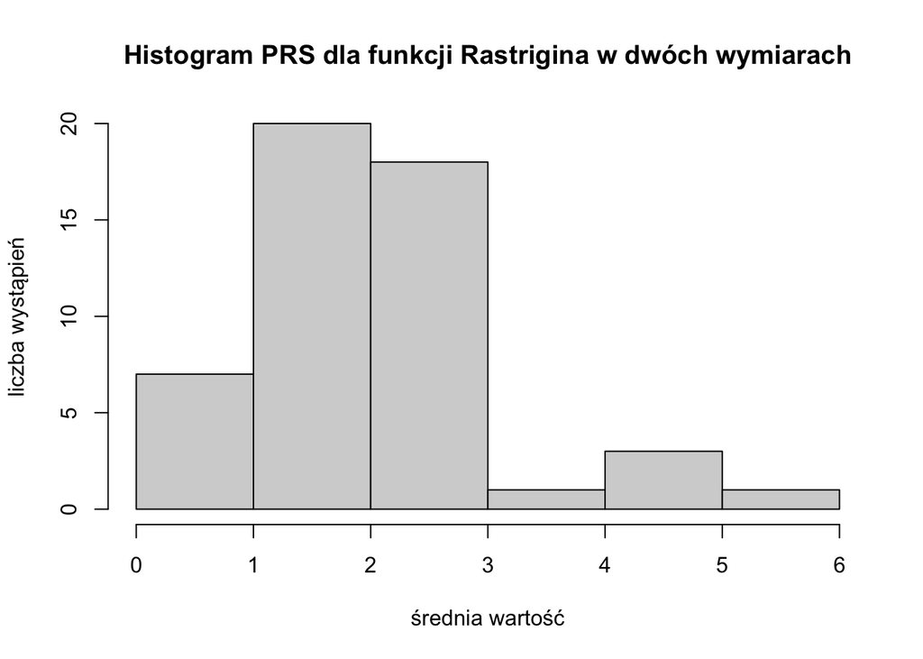

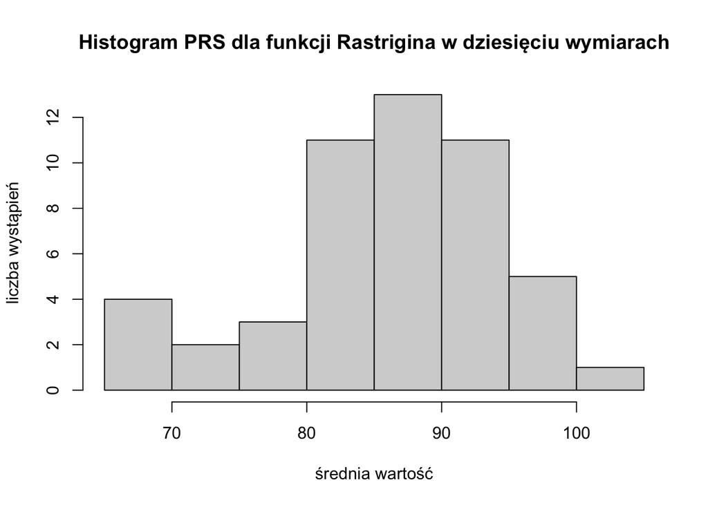

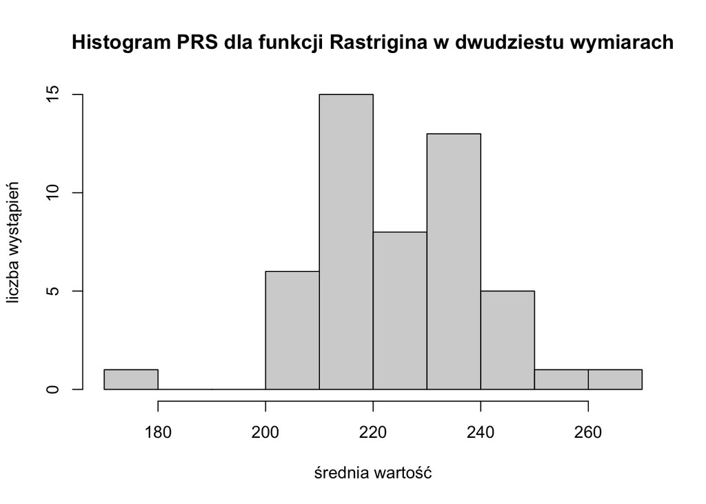

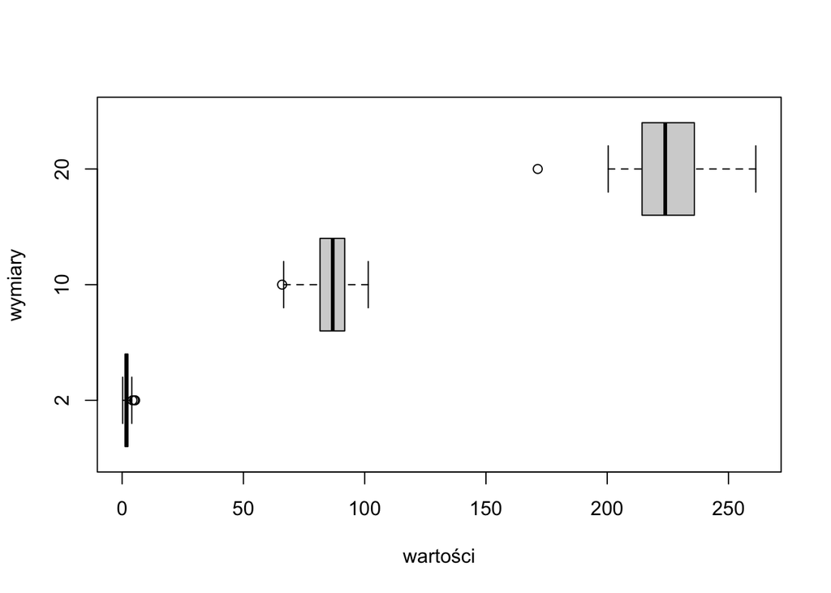

Łatwo zauważyć, że podobnie jak w przypadku funkcji Ackley’a, korzystając z algorytmu Poszukiwania przypadkowego wyniki nie są zgodne z powyższym stwierdzeniem. Im wyższy wymiar, tym większa wartość minimalna funkcji.

Na podstawie wykresów jesteśmy w stanie zauważyć, że wraz ze wzrostem wymiarów zwiększa się rozproszenie wartości funkcji. W odróżnieniu do funkcji Ackley’a mamy całkowicie odwrotne wartości rozproszenia wyników. Dla 2 wymiarów rozproszenie jest znacząco mniejsze od pozostałych, otrzymane wartości są bliskie zeru. Dla pozostałych funkcji wartości znacznie odbiegają od spodziewanych wyników. Również największy zasięg wartości położonych powyżej górnego i poniżej dolnego kwartyla przypada na funkcję 20 wymiarów.

## Algorytm genetyczny GA

*Ackley*

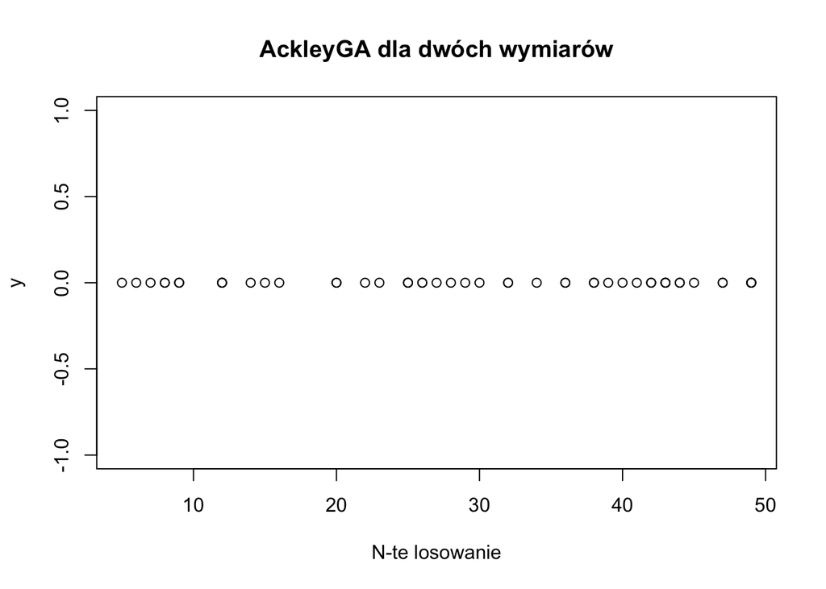

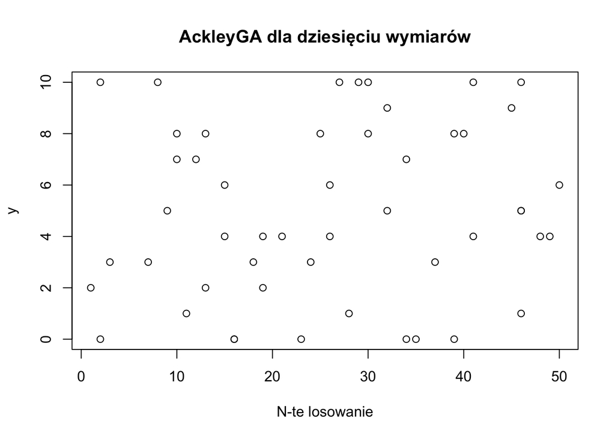

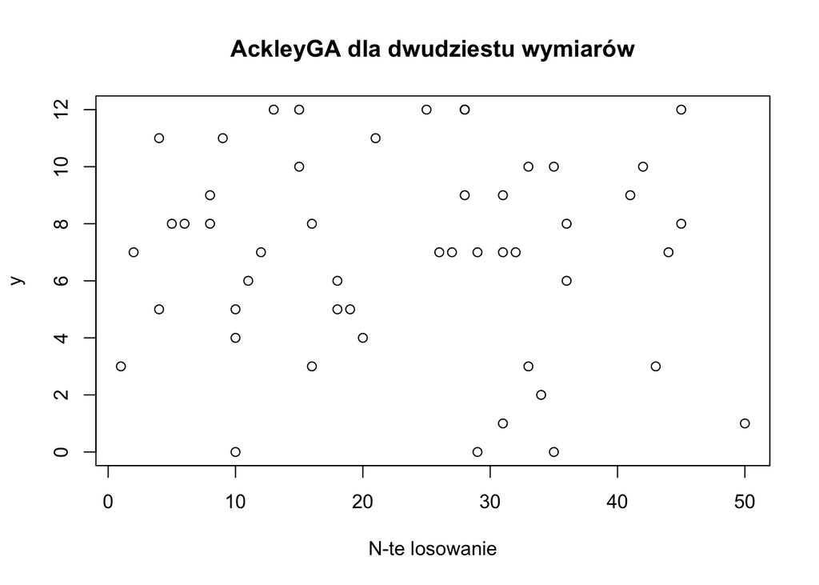

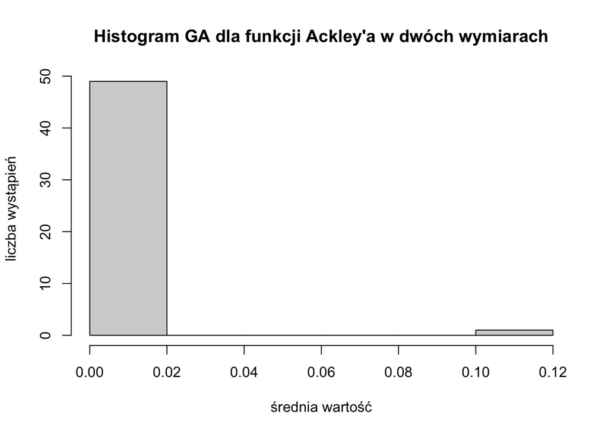

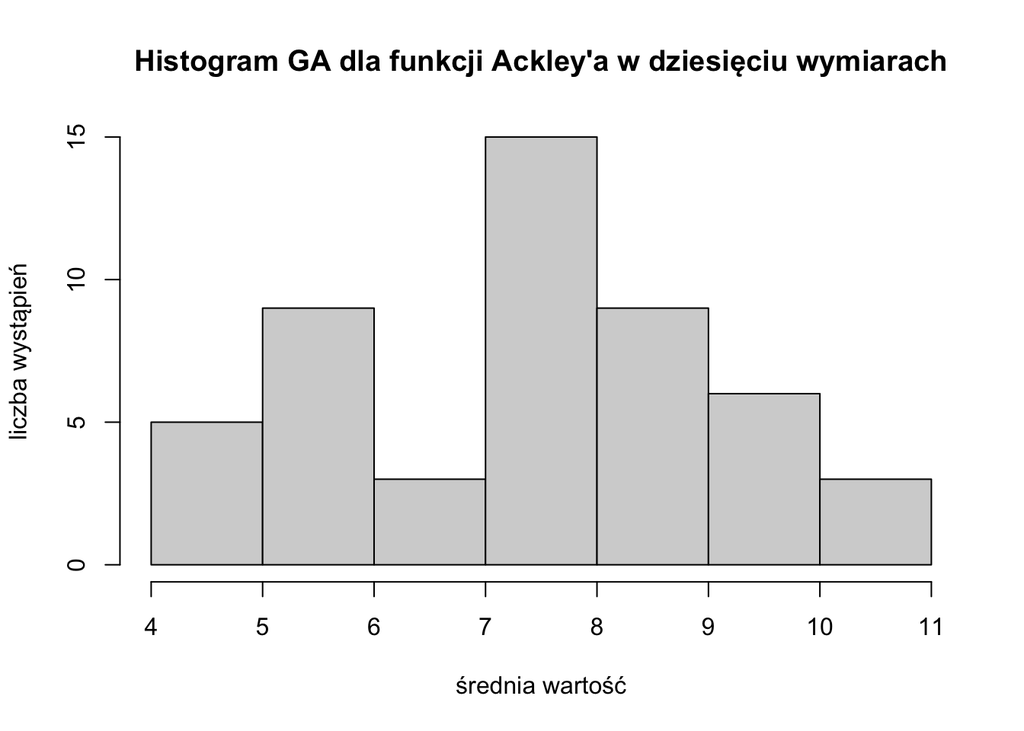

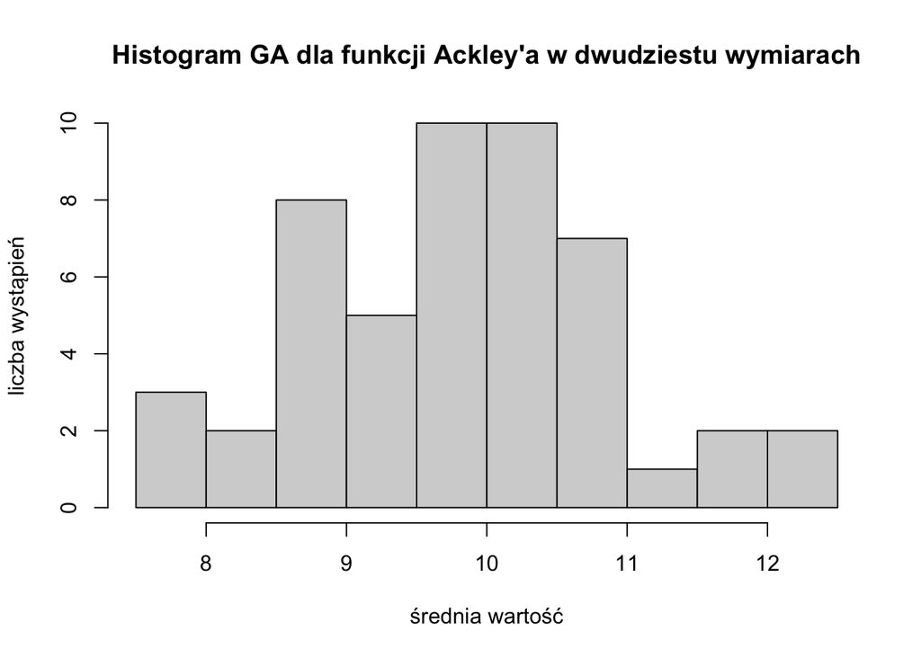

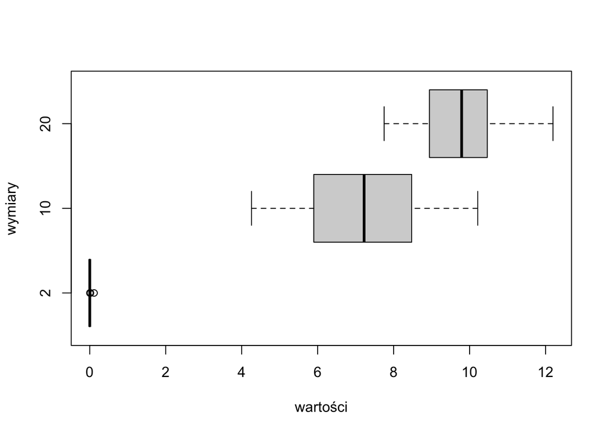

Wyniki dla algorytmu genetycznego są znacznie bliższe spodziewanego minimum funkcji. Widać jednak, że podobnie, jak dla algorytmu PRS, czym wyższy wymiar funkcji, tym większa znaleziona wartość.

Bazując na wykresach łatwo stwierdzić, że dla funkcji w 2 wymiarach algorytm znajduje wartości najmniej zróżnicowane i bliskie 0. Ma on rozkład asymetryczny prawostronny. Dla pozostałych dwóch funkcji ten zakres jest zdecydowanie mniej ograniczony, a otrzymane wartości są rozproszone. Mimo, że otrzymane dla nich wyniki są oddalone od spodziewanego zera, to są one mu bliższe, niż w przypadku algorytmu PRS dla tej samej funkcji.

*Rastrigin*

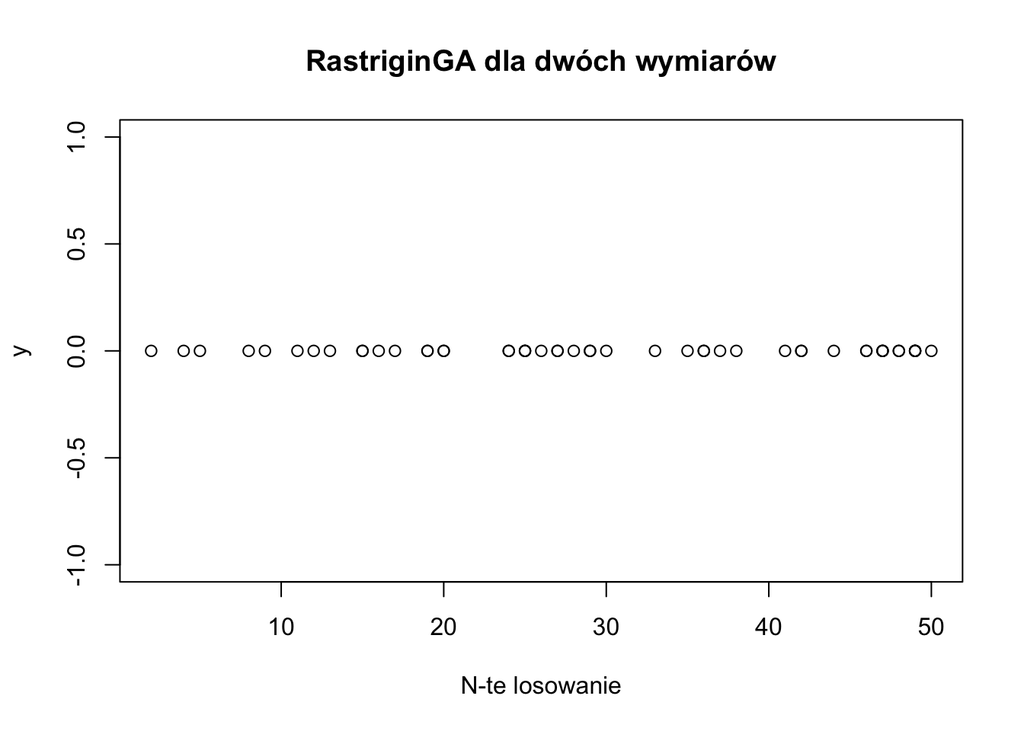

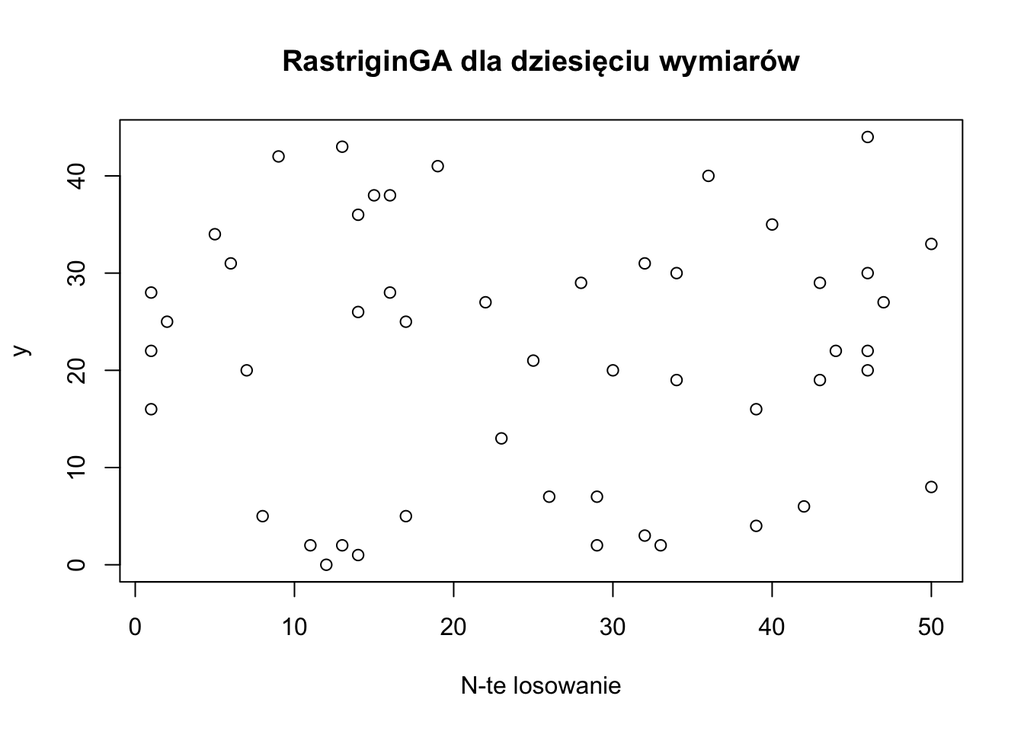

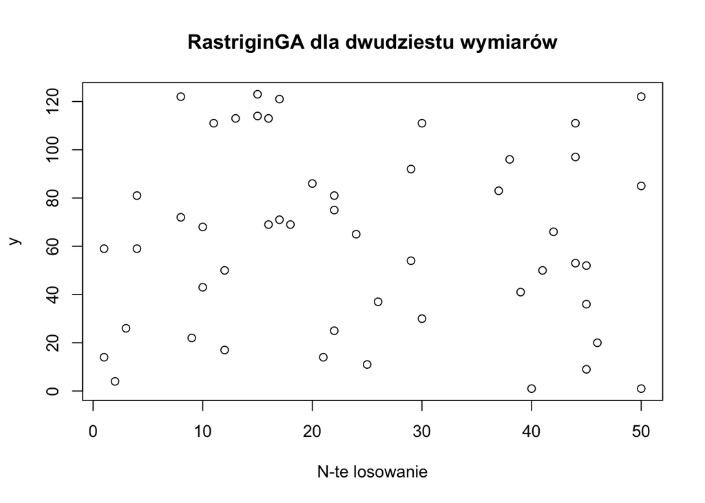

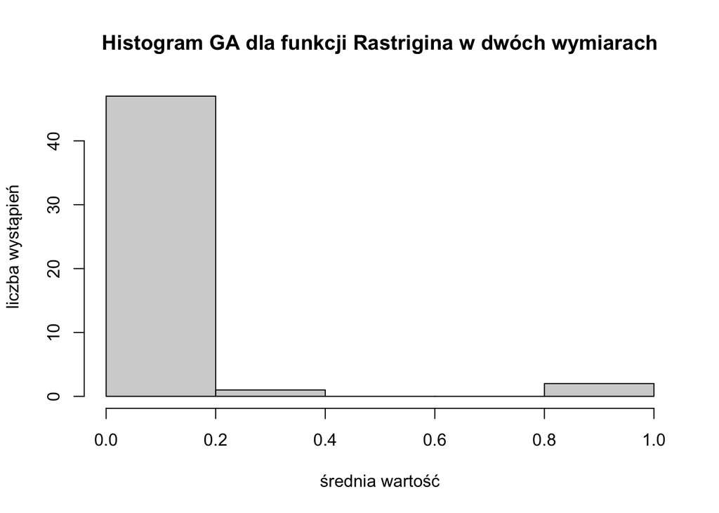

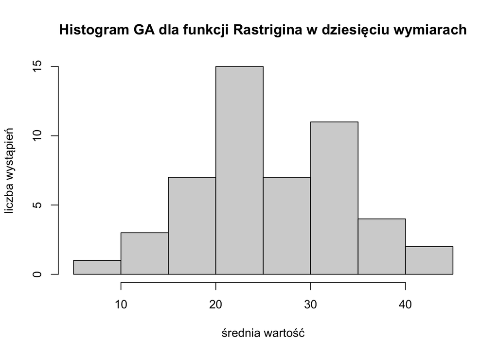

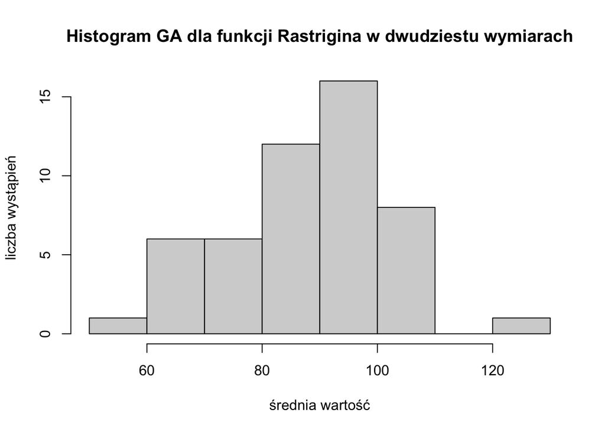

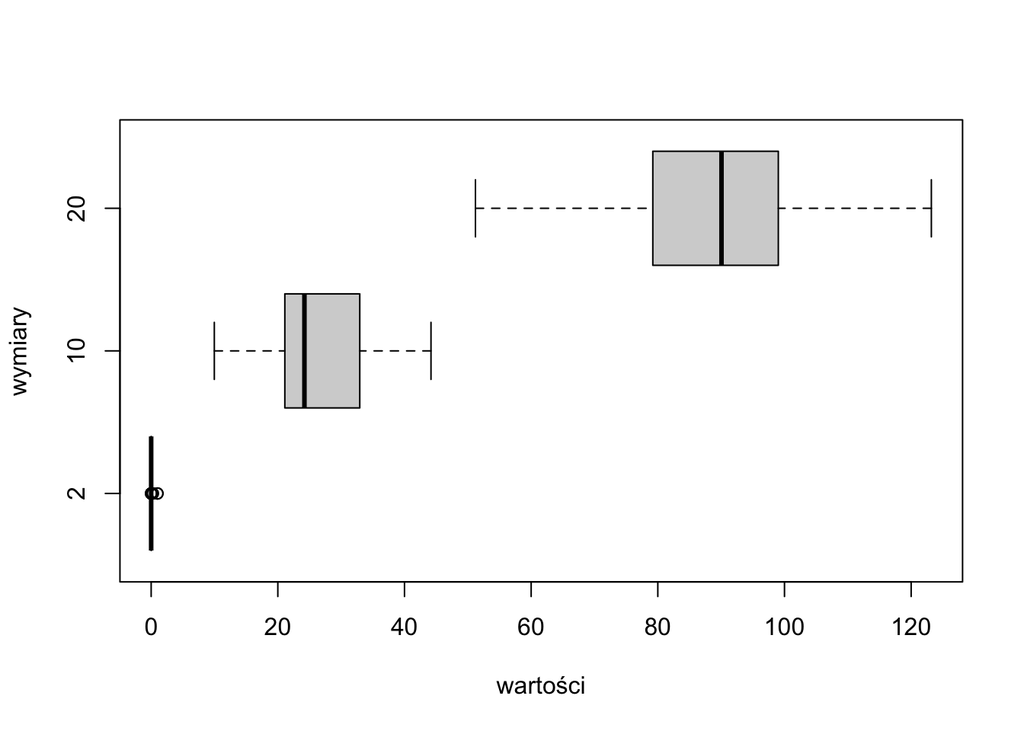

## Przedziały ufności

Przedziały ufności dla funkcji Ackley’a

2 wymiary PRS

```
## [1] 3.676459 4.408850
```

10 wymiarów PRS

```
## [1] 18.04514 18.48428
```

20 wymiarów PRS

```
## [1] 19.82052 19.96973
```

2 wymiary GA

```
## [1] -0.0003183228  0.0088744521
```

10 wymiarów GA

```
## [1] 6.831056 7.729802
```

20 wymiarów GA

```
## [1]  9.481858 10.081978
```

Przedział ufności dla funkcji Rastrigina

2 wymiary PRS

```
## [1] 1.641401 2.264891
```

10 wymiarów PRS

```
## [1] 83.49389 88.31516
```

20 wymiarów PRS

```
## [1] 220.0922 229.0677
```

2 wymiary GA

```
## [1] -0.008791901  0.104515479
```

10 wymiarów GA

```
## [1] 23.83270 28.37163
```

20 wymiarów GA

```
## [1] 84.38202 92.67328
```

## Testy hipotez zerowych

#### Hipoteza zerowa: funkcja posiada minimum równe 0

#### Hipoteza alternatywna: funkcja nie posiada minimum równego 0

Ackley

2 wymiary PRS

```
## [1] "Hipoteza zerowa może zostać odrzucona na rzecz hipotezy alternatywnej."
```

10 wymiarów PRS

```
## [1] "Hipoteza zerowa może zostać odrzucona na rzecz hipotezy alternatywnej."
```

20 wymiarów PRS

```
## [1] "Hipoteza zerowa może zostać odrzucona na rzecz hipotezy alternatywnej."
```

2 wymiary GA

```
## [1] "Hipoteza zerowa nie może zostać odrzucona."
```

10 wymiarów GA

```
## [1] "Hipoteza zerowa może zostać odrzucona na rzecz hipotezy alternatywnej."
```

20 wymiarów GA

```
## [1] "Hipoteza zerowa może zostać odrzucona na rzecz hipotezy alternatywnej."
```

Rastrigin

2 wymiary PRS

```
## [1] "Hipoteza zerowa może zostać odrzucona na rzecz hipotezy alternatywnej."
```

10 wymiarów PRS

```
## [1] "Hipoteza zerowa może zostać odrzucona na rzecz hipotezy alternatywnej."
```

20 wymiarów PRS

```
## [1] "Hipoteza zerowa może zostać odrzucona na rzecz hipotezy alternatywnej."
```

2 wymiary GA

```
## [1] "Hipoteza zerowa nie może zostać odrzucona."
```

10 wymiarów GA

```
## [1] "Hipoteza zerowa może zostać odrzucona na rzecz hipotezy alternatywnej."
```

20 wymiarów GA

```
## [1] "Hipoteza zerowa może zostać odrzucona na rzecz hipotezy alternatywnej."
```

W obydwu przypadkach wyniki pokazują, że w większości przypadków **hipoteza zerowa może zostać odrzucona na rzecz hipotezy alternatywnej.**  
Sądzimy, że wpływ na to ma dość duży rozrzut wyników w przypadku działania obydwu algorytmów. Wartości zbliżone do faktycznego wyniku występują wyłącznie przy algorytmie genetycznym dla dwóch wymiarów. W pozostałych przypadkach wyniki znacznie odbiegają od wartości faktycznej i są zawyżone.

#### Hipoteza zerowa: Algorytm PRS oraz GA dają identyczne wyniki (czy rozkłady są takie same)

#### Hipoteza alternatywna: Algorytm PRS oraz GA nie dają identycznych wyników (czyli rozkłady nie są takie same)

Ackley

2 wymiary

```
## [1] "Hipoteza zerowa może zostać odrzucona na rzecz hipotezy alternatywnej."
```

10 wymiarów

```
## [1] "Hipoteza zerowa może zostać odrzucona na rzecz hipotezy alternatywnej."
```

20 wymiarów

```
## [1] "Hipoteza zerowa może zostać odrzucona na rzecz hipotezy alternatywnej."
```

Rastrigin

2 wymiary PRS

```
## [1] "Hipoteza zerowa może zostać odrzucona na rzecz hipotezy alternatywnej."
```

10 wymiarów PRS

```
## [1] "Hipoteza zerowa może zostać odrzucona na rzecz hipotezy alternatywnej."
```

20 wymiarów PRS

```
## [1] "Hipoteza zerowa może zostać odrzucona na rzecz hipotezy alternatywnej."
```

Wyniki pokazują, że w większości przypadków **hipoteza zerowa może zostać odrzucona na rzecz hipotezy alternatywnej.**  
Algorytm poszukiwania przypadkowego polega na losowym wyborze punktów, zatem wartości funkcji nie muszą być w okolicach jej faktycznego minimum, jak ma to miejsce w Algorytmie genetycznym, zatem wyniki mogą się różnić, co pokazują testy hipotetyczne.